# CP06 - BMW vs. Volkswagen

Diego Senso González

30/11/2020

# Objetivo

El objetivo del presente informe es realizar un modelo GARCH con los datos de cotización de la empresa BMW y un modelo VAR mensual entre los dos activos (BMW y Volkswagen).

# Estimar el modelo garch de BMW

Se define la función “archTest”.

Extraemos los valores de la empresa BMW en las fechas que interesan para el análisis. Lo incluimos en un objeto “xData” para continuar el análisis. Utilizamos el paquete “Quantmod” para extraer los datos de las fechas necesarias para el análisis.

Se pasa al tratamiento de los datos. Este paso es útil para quedarnos con los rendimientos diarios, y además para suprimir los NAs de la muestra.

Se obtiene la gráfica de precio, rentabilidad y volatilidad de los datos de BMW.

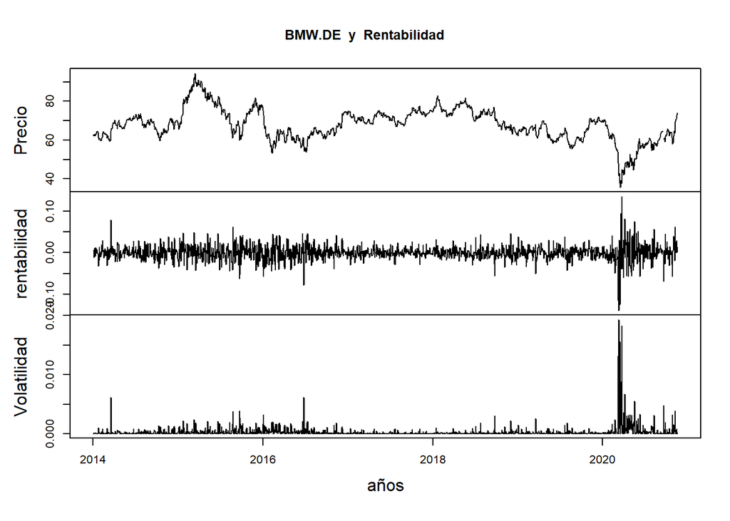

Se puede intuir un punto máximo que dataría de algún momento de principios de 2015 aproximadamente. Por otro lado, se observa una caída muy pronunciada a comienzos del 2020, muy probablemente indique la incertidumbre provocada en los mercados por la pandemia de Covid-19. Coindide además con los momentos de mayor rentabilidad y menor (mucha inestabilidad), algo que se puede observar directamente en la gráfica de abajo, la cual que representa la volatilidad.

Se representan los residuos gráficamente en ACF y PACF. A simple vista parece que no son ruido blanco. Esto no es deseable, ya que en muchos puntos las líneas superan las bandas discontinuas azules.

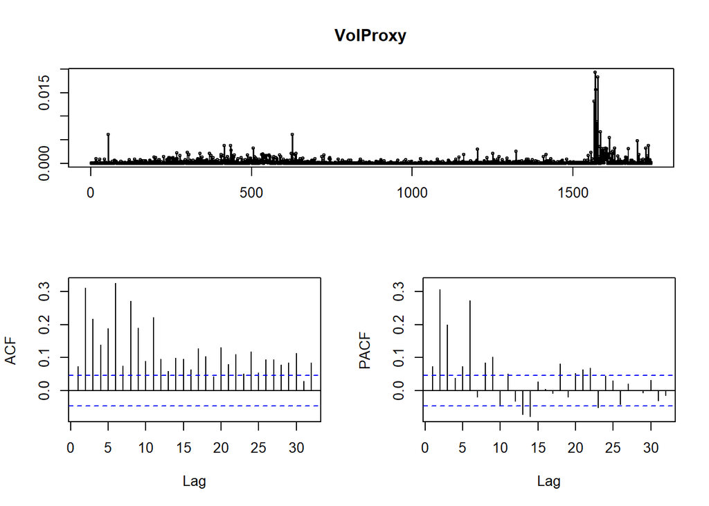

Para confirmar el gráfico anterior, es recomendable realizar el Ljung-Box Test, que maneja la hipótesis nula de que los residuos son ruido blanco.

```
##
##  Box-Ljung test
##
## data:  VolProxy
## X-squared = 760.2, df = 10, p-value < 2.2e-16
```

```
##
##  Box-Ljung test
##
## data:  VolProxy
## X-squared = 991.15, df = 20, p-value < 2.2e-16
```

```
##
##  Box-Ljung test
##
## data:  VolProxy
## X-squared = 1228.2, df = 40, p-value < 2.2e-16
```

Observamos que se rechaza la hipótesis nula, por lo que los residuos no son ruido blanco. Se pasa a realizar el LM test.

```
##
## Call:
## lm(formula = atsq ~ x)
##
## Residuals:
##        Min         1Q     Median         3Q        Max
## -0.0048020 -0.0002220 -0.0001055  0.0000524  0.0181138
##
## Coefficients:
##               Estimate Std. Error t value Pr(>|t|)
## (Intercept)  8.976e-05  2.562e-05   3.503 0.000471 ***
## x1          -3.675e-02  2.421e-02  -1.518 0.129172
## x2           2.366e-01  2.422e-02   9.769  < 2e-16 ***
## x3           9.281e-02  2.484e-02   3.736 0.000193 ***
## x4          -1.108e-02  2.495e-02  -0.444 0.657086
## x5           8.505e-02  2.494e-02   3.410 0.000664 ***
## x6           2.472e-01  2.503e-02   9.877  < 2e-16 ***
## x7          -2.314e-02  2.566e-02  -0.902 0.367218
## x8           1.242e-01  2.558e-02   4.856 1.31e-06 ***
## x9           7.709e-02  2.585e-02   2.983 0.002899 **
## x10         -4.122e-02  2.584e-02  -1.595 0.110893
## x11          7.633e-02  2.585e-02   2.953 0.003186 **
## x12         -4.531e-02  2.585e-02  -1.752 0.079868 .
## x13         -8.355e-02  2.575e-02  -3.245 0.001199 **
## x14         -8.893e-02  2.583e-02  -3.444 0.000588 ***
## x15          1.654e-02  2.520e-02   0.656 0.511784
## x16         -1.208e-02  2.512e-02  -0.481 0.630758
## x17         -5.091e-03  2.520e-02  -0.202 0.839908
## x18          6.874e-02  2.508e-02   2.740 0.006203 **
## x19         -1.626e-02  2.444e-02  -0.665 0.506072
## x20          5.415e-02  2.444e-02   2.216 0.026847 *
## ---
## Signif. codes:  0 '***' 0.001 '**' 0.01 '*' 0.05 '.' 0.1 ' ' 1
##
## Residual standard error: 0.0008748 on 1702 degrees of freedom
## Multiple R-squared:  0.2416, Adjusted R-squared:  0.2327
## F-statistic: 27.12 on 20 and 1702 DF,  p-value: < 2.2e-16
```

Procedemos a estimar un modelo ARCH (modelo autorregresivo con heterocedasticidad condicional). Tras ello se puede observar la información del AIC y resto de contrastes que realiza el modelo. Además, se grafican los residuos El modelo ARCH es propio para analizar series temporales y es útil para describir y analizar la distribución de los errores. En primer lugar se estima dicho modelo, y después se pasa a graficar los residuos.

```
##
## Title:
##  GARCH Modelling
##
## Call:
##  garchFit(formula = ~1 + garch(1, 0), data = dRentCont, trace = F)
##
## Mean and Variance Equation:
##  data ~ 1 + garch(1, 0)
## <environment: 0x00000000289ad6e8>
##  [data = dRentCont]
##
## Conditional Distribution:
##  norm
##
## Coefficient(s):
##         mu       omega      alpha1
## 0.00016803  0.00022991  0.31928300
##
## Std. Errors:
##  based on Hessian
##
## Error Analysis:
##         Estimate  Std. Error  t value Pr(>|t|)
## mu     0.0001680   0.0003911    0.430    0.667
## omega  0.0002299   0.0000104   22.116  < 2e-16 ***
## alpha1 0.3192830   0.0457047    6.986 2.83e-12 ***
## ---
## Signif. codes:  0 '***' 0.001 '**' 0.01 '*' 0.05 '.' 0.1 ' ' 1
##
## Log Likelihood:
##  4612.703    normalized:  2.646416
##
## Description:
##  Mon Nov 30 20:06:39 2020 by user: Diego
##
##
## Standardised Residuals Tests:
##                                 Statistic p-Value
##  Jarque-Bera Test   R    Chi^2  3775.781  0
##  Shapiro-Wilk Test  R    W      0.9374354 0
##  Ljung-Box Test     R    Q(10)  23.49578  0.009057351
##  Ljung-Box Test     R    Q(15)  31.70679  0.00705628
##  Ljung-Box Test     R    Q(20)  37.60029  0.009905389
##  Ljung-Box Test     R^2  Q(10)  317.7572  0
##  Ljung-Box Test     R^2  Q(15)  380.1394  0
##  Ljung-Box Test     R^2  Q(20)  471.9584  0
##  LM Arch Test       R    TR^2   231.7435  0
##
## Information Criterion Statistics:
##       AIC       BIC       SIC      HQIC
## -5.289390 -5.279986 -5.289396 -5.285913
```

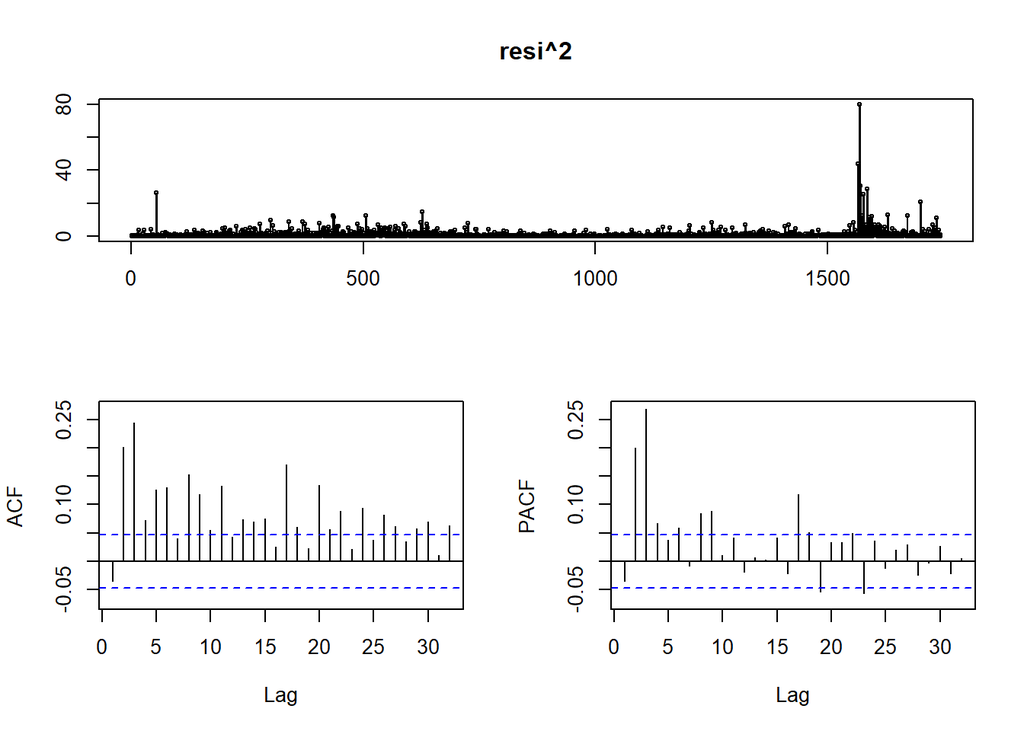

Dadas las gráfica inferiores, cabe interpretar que los residuos no son ruido blanco. A continuación, se pasa a estimar un modelo GARCH (1,1), que en realidad es un ARMA (1,1) sobre la varianza de los errores. Esta clase de modelos sirve para estudiar la volatilidad de los rendimientos del activo o activos en cuestión. Al igual en el modelo ARCH, se grafican también los errores.

```
##
## Title:
##  GARCH Modelling
##
## Call:
##  garchFit(formula = ~1 + garch(1, 1), data = dRentCont, trace = F)
##
## Mean and Variance Equation:
##  data ~ 1 + garch(1, 1)
## <environment: 0x000000001861d648>
##  [data = dRentCont]
##
## Conditional Distribution:
##  norm
##
## Coefficient(s):
##         mu       omega      alpha1       beta1
## 3.0684e-04  2.4947e-06  5.0081e-02  9.4263e-01
##
## Std. Errors:
##  based on Hessian
##
## Error Analysis:
##         Estimate  Std. Error  t value Pr(>|t|)
## mu     3.068e-04   3.362e-04    0.913   0.3615
## omega  2.495e-06   9.797e-07    2.546   0.0109 *
## alpha1 5.008e-02   8.035e-03    6.233 4.58e-10 ***
## beta1  9.426e-01   9.568e-03   98.520  < 2e-16 ***
## ---
## Signif. codes:  0 '***' 0.001 '**' 0.01 '*' 0.05 '.' 0.1 ' ' 1
##
## Log Likelihood:
##  4784.372    normalized:  2.744906
##
## Description:
##  Mon Nov 30 20:06:39 2020 by user: Diego
##
##
## Standardised Residuals Tests:
##                                 Statistic p-Value
##  Jarque-Bera Test   R    Chi^2  749.8794  0
##  Shapiro-Wilk Test  R    W      0.9721869 0
##  Ljung-Box Test     R    Q(10)  22.16379  0.01429161
##  Ljung-Box Test     R    Q(15)  26.52681  0.0328368
##  Ljung-Box Test     R    Q(20)  32.65733  0.03677834
##  Ljung-Box Test     R^2  Q(10)  21.37204  0.01864359
##  Ljung-Box Test     R^2  Q(15)  22.78481  0.08881694
##  Ljung-Box Test     R^2  Q(20)  26.20932  0.1590093
##  LM Arch Test       R    TR^2   21.86715  0.03903594
##
## Information Criterion Statistics:
##       AIC       BIC       SIC      HQIC
## -5.485223 -5.472685 -5.485233 -5.480587
```

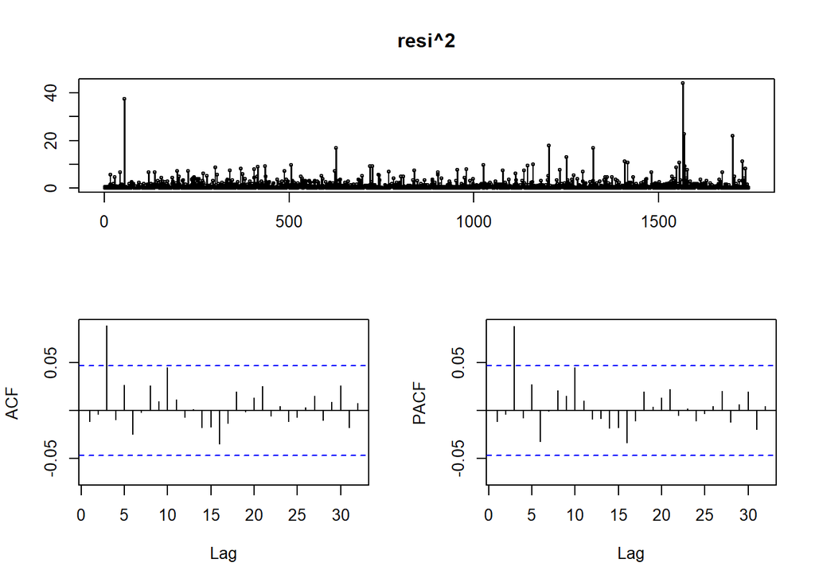

Se estima un nuevo modelo GARCH esta vez modificando el parámetro “cond.dist” que sirve para escoger la distribución a seguir por el modelo. En caso de no especificarlo, el valor por defecto es el de la distribución normal. A continuación, se grafica la volatilidad y los residuos derivados de este modelo.

```
##
## Title:
##  GARCH Modelling
##
## Call:
##  garchFit(formula = ~1 + garch(1, 1), data = dRentCont, cond.dist = "std",
##     trace = F)
##
## Mean and Variance Equation:
##  data ~ 1 + garch(1, 1)
## <environment: 0x0000000026f27c38>
##  [data = dRentCont]
##
## Conditional Distribution:
##  std
##
## Coefficient(s):
##         mu       omega      alpha1       beta1       shape
## 1.2617e-05  2.0402e-06  4.7209e-02  9.4807e-01  4.9641e+00
##
## Std. Errors:
##  based on Hessian
##
## Error Analysis:
##         Estimate  Std. Error  t value Pr(>|t|)
## mu     1.262e-05   3.088e-04    0.041   0.9674
## omega  2.040e-06   9.692e-07    2.105   0.0353 *
## alpha1 4.721e-02   9.980e-03    4.730 2.24e-06 ***
## beta1  9.481e-01   1.053e-02   90.008  < 2e-16 ***
## shape  4.964e+00   6.045e-01    8.212 2.22e-16 ***
## ---
## Signif. codes:  0 '***' 0.001 '**' 0.01 '*' 0.05 '.' 0.1 ' ' 1
##
## Log Likelihood:
##  4856.229    normalized:  2.786133
##
## Description:
##  Mon Nov 30 20:06:40 2020 by user: Diego
##
##
## Standardised Residuals Tests:
##                                 Statistic p-Value
##  Jarque-Bera Test   R    Chi^2  779.5317  0
##  Shapiro-Wilk Test  R    W      0.9718239 0
##  Ljung-Box Test     R    Q(10)  22.35225  0.01340731
##  Ljung-Box Test     R    Q(15)  26.62859  0.03191226
##  Ljung-Box Test     R    Q(20)  32.75372  0.03589998
##  Ljung-Box Test     R^2  Q(10)  24.785    0.005768285
##  Ljung-Box Test     R^2  Q(15)  26.15726  0.03640188
##  Ljung-Box Test     R^2  Q(20)  29.76094  0.07382102
##  LM Arch Test       R    TR^2   25.29787  0.01347274
##
## Information Criterion Statistics:
##       AIC       BIC       SIC      HQIC
## -5.566528 -5.550856 -5.566544 -5.560733
```

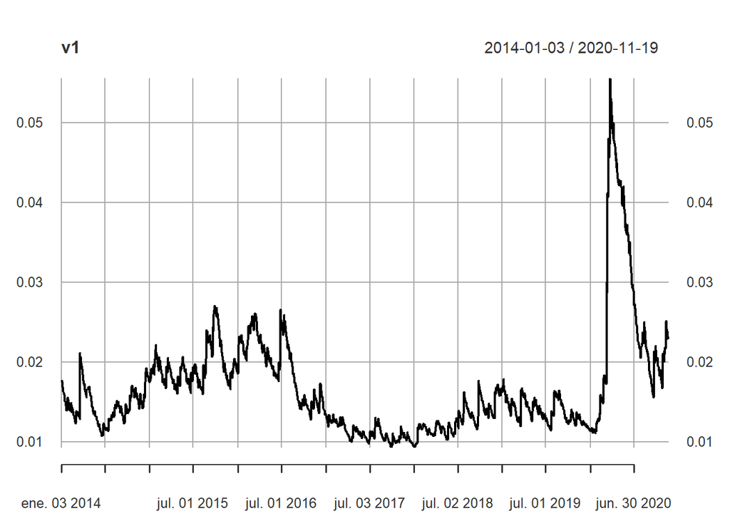

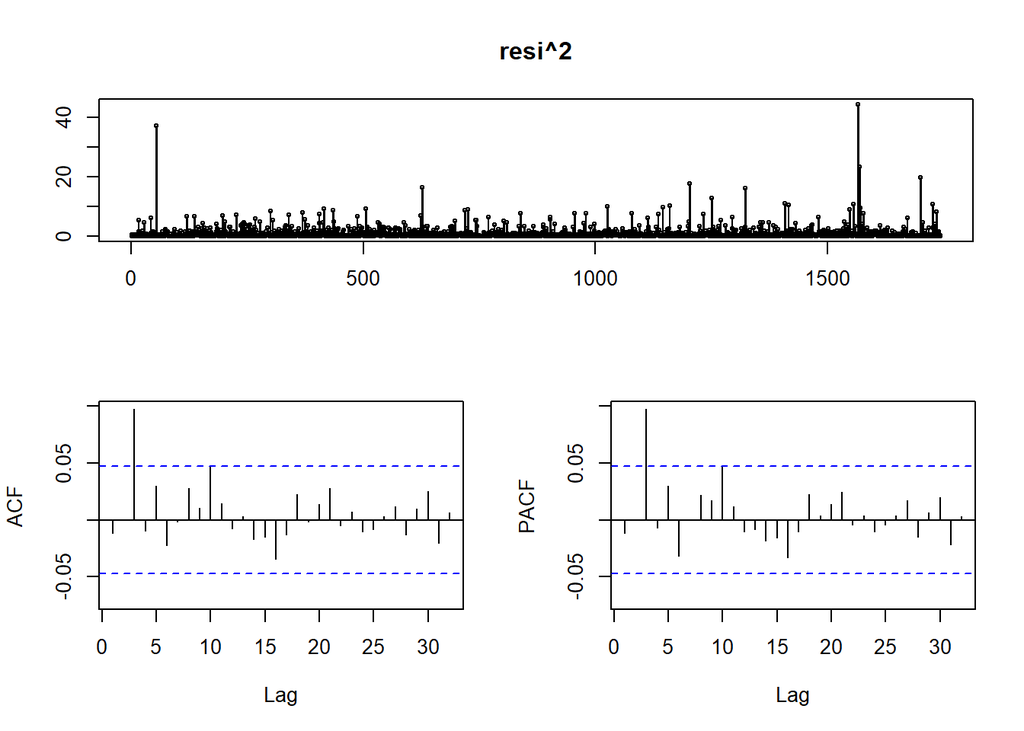

Se realiza la predicción con el modelo “m3”. Primero se hace sobre los 10 periodos siguientes y luego sobre 20. En un caso se ordena que grafique un total de 100 observaciones dentro de un intervalo de confianza del 90%.

| meanForecast | meanError | standardDeviation |
| --- | --- | --- |
| 1.261672e-05 | 0.02226151 | 0.02226151 |
| 1.261672e-05 | 0.02225474 | 0.02225474 |
| 1.261672e-05 | 0.02224801 | 0.02224801 |
| 1.261672e-05 | 0.02224130 | 0.02224130 |
| 1.261672e-05 | 0.02223462 | 0.02223462 |
| 1.261672e-05 | 0.02222798 | 0.02222798 |
| 1.261672e-05 | 0.02222136 | 0.02222136 |
| 1.261672e-05 | 0.02221477 | 0.02221477 |
| 1.261672e-05 | 0.02220821 | 0.02220821 |
| 1.261672e-05 | 0.02220168 | 0.02220168 |

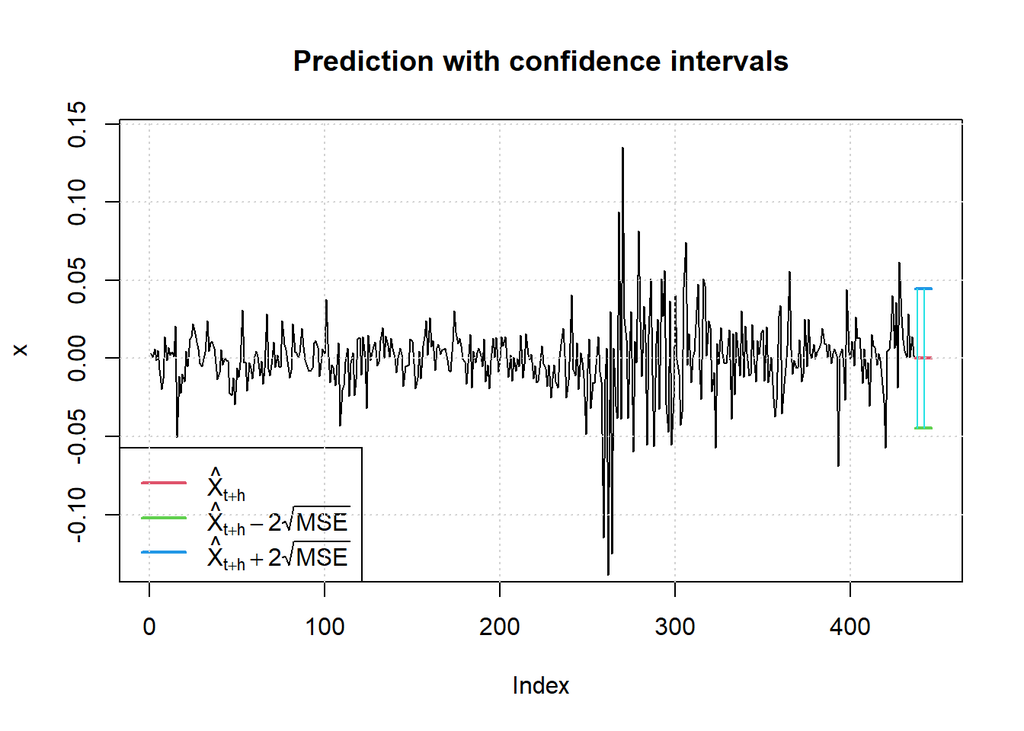

| meanForecast | meanError | standardDeviation | lowerInterval | upperInterval |
| --- | --- | --- | --- | --- |
| 1.261672e-05 | 0.02226151 | 0.02226151 | -0.04451040 | 0.04453564 |
| 1.261672e-05 | 0.02225474 | 0.02225474 | -0.04449687 | 0.04452210 |
| 1.261672e-05 | 0.02224801 | 0.02224801 | -0.04448340 | 0.04450863 |
| 1.261672e-05 | 0.02224130 | 0.02224130 | -0.04446998 | 0.04449522 |
| 1.261672e-05 | 0.02223462 | 0.02223462 | -0.04445663 | 0.04448186 |
| 1.261672e-05 | 0.02222798 | 0.02222798 | -0.04444333 | 0.04446857 |
| 1.261672e-05 | 0.02222136 | 0.02222136 | -0.04443010 | 0.04445533 |
| 1.261672e-05 | 0.02221477 | 0.02221477 | -0.04441692 | 0.04444215 |
| 1.261672e-05 | 0.02220821 | 0.02220821 | -0.04440380 | 0.04442904 |
| 1.261672e-05 | 0.02220168 | 0.02220168 | -0.04439074 | 0.04441597 |

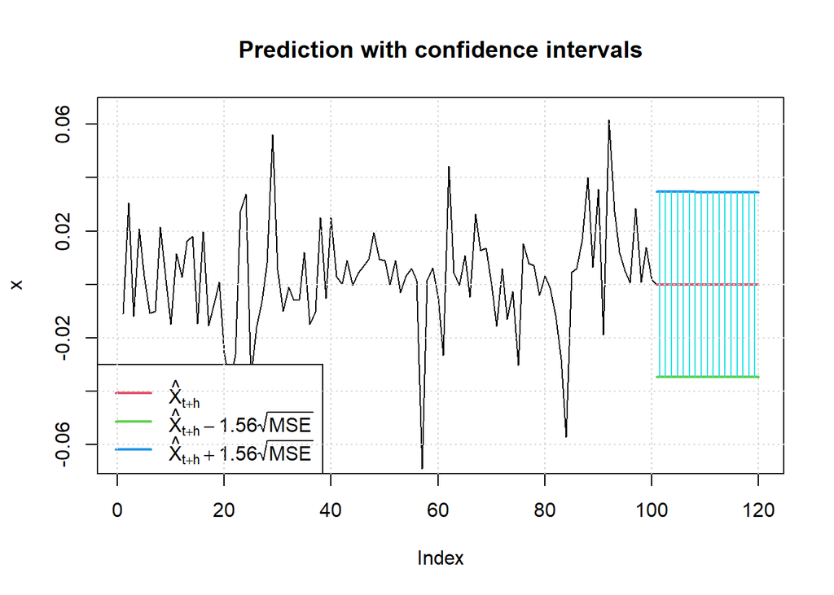

| meanForecast | meanError | standardDeviation | lowerInterval | upperInterval |
| --- | --- | --- | --- | --- |
| 1.261672e-05 | 0.02226151 | 0.02226151 | -0.03470581 | 0.03473104 |
| 1.261672e-05 | 0.02225474 | 0.02225474 | -0.03469526 | 0.03472049 |
| 1.261672e-05 | 0.02224801 | 0.02224801 | -0.03468475 | 0.03470998 |
| 1.261672e-05 | 0.02224130 | 0.02224130 | -0.03467429 | 0.03469952 |
| 1.261672e-05 | 0.02223462 | 0.02223462 | -0.03466388 | 0.03468911 |
| 1.261672e-05 | 0.02222798 | 0.02222798 | -0.03465351 | 0.03467874 |
| 1.261672e-05 | 0.02222136 | 0.02222136 | -0.03464319 | 0.03466842 |
| 1.261672e-05 | 0.02221477 | 0.02221477 | -0.03463291 | 0.03465815 |
| 1.261672e-05 | 0.02220821 | 0.02220821 | -0.03462268 | 0.03464792 |
| 1.261672e-05 | 0.02220168 | 0.02220168 | -0.03461250 | 0.03463773 |

[output cut: 10 more lines]

# Plantear un modelo VAR mensual entre los dos activos.

El modelo VAR (vectores autorregresivos) trata de contrastar si existe una retroalimentación o una mutua influencia entre dos variables al mismo tiempo. Se proceden a cargar los datos de las dos empresas sobre las que se quiere estudiar la posible relación (BMW y Volkswagen):

Se obtienen los rendimientos por mes en ambos casos, pues se desea estimar un modelo VAR mensual entre ambas.

Se genera un vector de datos con los rendimientos de ambas empresas.

Se pasa a estimar un modelo VAR y a imprimir los resultados. A continuación, se mide tanto la causalidad de ambas (para ver si hay relación de que una determina la otra) como la repsuesta al impulso. Como último paso, se procede a predecir los siguientes ocho periodos, marcando un intervalo de confianza del 95%.

```
##
## VAR Estimation Results:
## =========================
## Endogenous variables: BMW, VOL
## Deterministic variables: none
## Sample size: 82
## Log Likelihood: 200.733
## Roots of the characteristic polynomial:
## 0.2881 0.2881
## Call:
## VAR(y = vY, type = "none")
##
##
## Estimation results for equation BMW:
## ====================================
## BMW = BMW.l1 + VOL.l1
##
##        Estimate Std. Error t value Pr(>|t|)
## BMW.l1   0.2830     0.1637   1.729  0.08772 .
## VOL.l1  -0.3543     0.1242  -2.852  0.00552 **
## ---
## Signif. codes:  0 '***' 0.001 '**' 0.01 '*' 0.05 '.' 0.1 ' ' 1
##
##
## Residual standard error: 0.07721 on 80 degrees of freedom
## Multiple R-Squared: 0.0945,  Adjusted R-squared: 0.07186
## F-statistic: 4.174 on 2 and 80 DF,  p-value: 0.01886
##
##
## Estimation results for equation VOL:
## ====================================
## VOL = BMW.l1 + VOL.l1
##
##        Estimate Std. Error t value Pr(>|t|)
## BMW.l1   0.5204     0.2091   2.489   0.0149 *
## VOL.l1  -0.3581     0.1586  -2.257   0.0267 *
## ---
## Signif. codes:  0 '***' 0.001 '**' 0.01 '*' 0.05 '.' 0.1 ' ' 1
##
##
## Residual standard error: 0.09861 on 80 degrees of freedom
## Multiple R-Squared: 0.07673, Adjusted R-squared: 0.05365
## F-statistic: 3.324 on 2 and 80 DF,  p-value: 0.04104
##
##
##
## Covariance matrix of residuals:
##          BMW      VOL
## BMW 0.005927 0.005543
## VOL 0.005543 0.009701
##
## Correlation matrix of residuals:
##       BMW   VOL
## BMW 1.000 0.731
## VOL 0.731 1.000
```

```
## $Granger
##
##  Granger causality H0: BMW do not Granger-cause VOL
##
## data:  VAR object model.var1
## F-Test = 6.193, df1 = 1, df2 = 160, p-value = 0.01385
##
##
## $Instant
##
##  H0: No instantaneous causality between: BMW and VOL
##
## data:  VAR object model.var1
## Chi-squared = 28.594, df = 1, p-value = 8.927e-08
```

```
##
## Impulse response coefficients
## $BMW
##                 BMW           VOL
##  [1,]  7.720553e-02  7.215505e-02
##  [2,] -3.713073e-03  1.433906e-02
##  [3,] -6.130922e-03 -7.066521e-03
##  [4,]  7.684115e-04 -6.600561e-04
##  [5,]  4.513166e-04  6.362027e-04
##  [6,] -9.766679e-05  7.048114e-06
##  [7,] -3.013800e-05 -5.334655e-05
##  [8,]  1.037028e-05  3.418754e-06
##  [9,]  1.723723e-06  4.172239e-06
## [10,] -9.903139e-07 -5.969695e-07
## [11,] -6.877614e-08 -3.015742e-07
```

[output cut: 74 more lines]

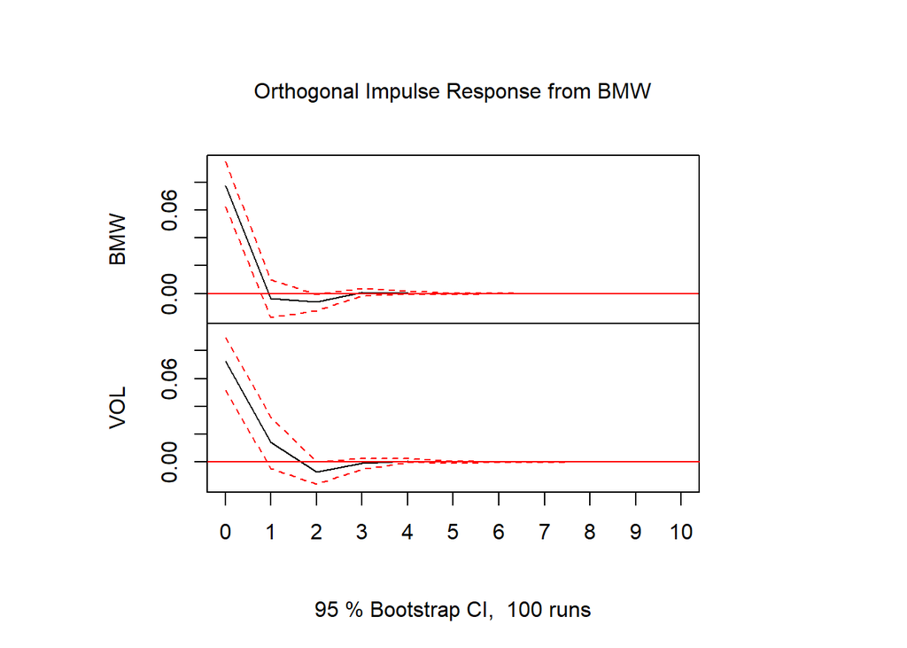

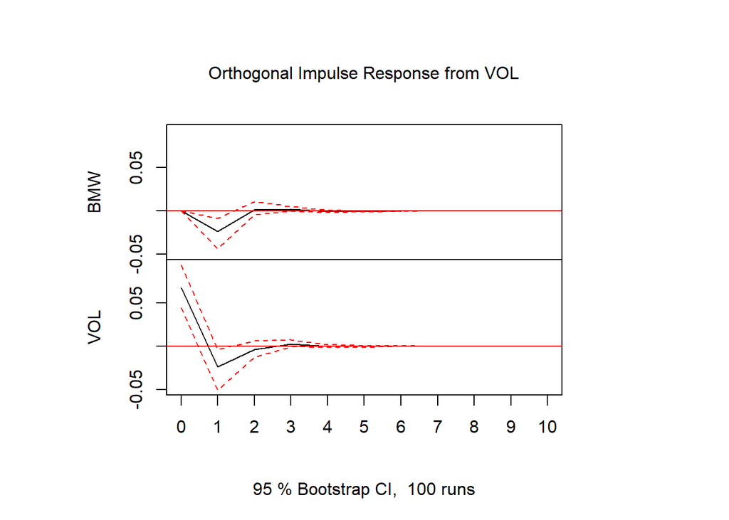

```
## $BMW
##               fcst      lower     upper        CI
## [1,] -3.765025e-03 -0.1550851 0.1475550 0.1513201
## [2,] -2.139204e-02 -0.1799135 0.1371294 0.1585214
## [3,]  1.918137e-03 -0.1570967 0.1609330 0.1590148
## [4,]  1.632003e-03 -0.1574310 0.1606950 0.1590630
## [5,] -2.817326e-04 -0.1593481 0.1587847 0.1590664
## [6,] -1.143436e-04 -0.1591811 0.1589524 0.1590667
## [7,]  3.197142e-05 -0.1590348 0.1590987 0.1590668
## [8,]  7.093218e-06 -0.1590597 0.1590739 0.1590668
##
## $VOL
##               fcst      lower     upper        CI
## [1,]  5.737372e-02 -0.1359006 0.2506480 0.1932743
## [2,] -2.250286e-02 -0.2234255 0.1784198 0.2009227
## [3,] -3.074230e-03 -0.2046095 0.1984610 0.2015353
## [4,]  2.098922e-03 -0.1994901 0.2036879 0.2015890
## [5,]  9.768947e-05 -0.2014954 0.2016907 0.2015930
## [6,] -1.815845e-04 -0.2017750 0.2014118 0.2015934
## [7,]  5.518521e-06 -0.2015879 0.2015990 0.2015935
## [8,]  1.466096e-05 -0.2015788 0.2016081 0.2015935
```

La conclusión que se deseaba extraer de la estimación de este modelo VAR entre BMW y Volkswagen es si existía causalidad entre ellas. A la vista de los resultados, cabe concluir que se rechaza la hipótesis nula de que una no causa la otra. Por lo tanto, cabe concluir que sí existe causalidad entre los datos de las series temporales de estas empresas.